# 004_troubleshooting.Rmd

## Use test data set through whole pipeline

Following the format of the previous trouble shoot `004_troubleshooting.Rmd`, I’ll step through the replacement steps

### Load into `pepdiff` data stucture

```r
library(pepdiff)
pdiff <- import_data(here::here("cleaned", "005_selected_ts_1.csv"),
                 gene_id = "molecule_list_name",
                 treatment = "genotype",
                 peptide = "peptide_modified_sequence",
                 seconds = "timepoint")
pdiff
```

```
## # A tibble: 360 × 8
##    id           gene_id    peptide   treatment seconds bio_rep tech_rep    quant
##    <chr>        <chr>      <chr>     <chr>       <dbl> <chr>   <chr>       <dbl>
##  1 gi|14560172… gi|145601… KLS[+80]… Guy11           0 1       1         1.03e-3
##  2 gi|14560172… gi|145601… KLS[+80]… Guy11           0 1       2         1.13e-3
##  3 gi|14560172… gi|145601… KLS[+80]… Guy11           0 2       1        NA
##  4 gi|14560172… gi|145601… KLS[+80]… Guy11           0 2       2        NA
##  5 gi|14560172… gi|145601… KLS[+80]… Guy11           0 3       1         4.00e-4
##  6 gi|14560172… gi|145601… KLS[+80]… Guy11           0 3       2         2.32e-4
##  7 gi|14560172… gi|145601… KLS[+80]… Guy11           1 1       1         3.93e-4
##  8 gi|14560172… gi|145601… KLS[+80]… Guy11           1 1       2         1.67e-4
##  9 gi|14560172… gi|145601… KLS[+80]… Guy11           1 2       1         2.98e-4
## 10 gi|14560172… gi|145601… KLS[+80]… Guy11           1 2       2        NA
## # … with 350 more rows
```

This is where we would normally start from. The code below is discussed in the previous document, so here it just runs and shows a heatmap of biorep level data with combined tech rep info

```r
library(rlang)
combine_tech_reps <- function(df){
  df %>%
    dplyr::group_by(.data$gene_id, .data$peptide, .data$treatment, .data$seconds, .data$bio_rep) %>%
    dplyr::summarize(mean_tr_quant = mean(.data$quant, na.rm = TRUE) )
}


matrix_data <- function(df){
  df <- combine_tech_reps(df)
  row_info <- dplyr::group_by(df, .data$gene_id, .data$peptide, .data$treatment, .data$seconds, .data$bio_rep) %>%
    dplyr::summarize(col_count = dplyr::n() )

  dm <- df %>%
    tidyr::pivot_wider(names_from = c(.data$treatment, .data$seconds, .data$bio_rep), values_from = .data$mean_tr_quant) %>%
    as.matrix()

  row_info <- dm[,c("gene_id", "peptide")]
  col_info <- colnames(dm[,3:length(colnames(dm))])
  dm <-  matrix(as.numeric(dm[,3:ncol(dm)]), nrow=nrow(dm) )
  colnames(dm) <- col_info
  return(list( row_info = row_info, data = dm ))
}

mdata <- matrix_data(pdiff)
mdata$data
```

```
##         dpmk1_0_1   dpmk1_0_2   dpmk1_0_3    dpmk1_1_1    dpmk1_1_2
## [1,] 0.0004039197 0.001229286          NA 0.0002855887 0.0003080515
## [2,] 0.0022220345 0.003035265 2.41783e-04 0.0012118765 0.0008760315
## [3,]           NA          NA          NA           NA           NA
## [4,] 0.0005590420 0.000537064 9.63572e-05 0.0004084508 0.0006465552
## [5,] 0.0001298511          NA          NA 0.0009290811 0.0009232904
##         dpmk1_1_3  dpmk1_1.5_1  dpmk1_1.5_2  dpmk1_1.5_3    dpmk1_2_1
## [1,] 0.0003350321 0.0002246997 0.0004555553           NA 0.0001741449
## [2,] 0.0013864871 0.0006650540 0.0011309654 1.953995e-04 0.0010957020
## [3,]           NA           NA           NA           NA 0.0002519993
## [4,] 0.0004033864 0.0001424259 0.0005462359 7.998513e-05 0.0003161268
## [5,] 0.0002259952 0.0015678389 0.0008516205 1.656680e-04 0.0031157185
##         dpmk1_2_2    dpmk1_2_3    dpmk1_4_1    dpmk1_4_2    dpmk1_4_3
## [1,] 0.0002511316 3.523301e-04 0.0002638939 0.0004472841 0.0002630847
## [2,] 0.0012302161 1.711638e-03 0.0011648545 0.0009591751 0.0008175470
```

[output cut: 33 more lines]

```r
mdata$row_info
```

```
##      gene_id
## [1,] "gi|145601729|ref|XP_363034.2|"
## [2,] "gi|145602009|ref|XP_359520.2|"
## [3,] "gi|145602328|ref|XP_001403655.1|"
## [4,] "gi|39976863|ref|XP_369819.1|"
## [5,] "MGG_12865T0"
##      peptide
## [1,] "KLS[+80]ASGS[+80]PGSVNLGR"
## [2,] "QTRT[+80]PS[+80]PASNGPAPLGVAEGPITPR"
## [3,] "AAEEDVTTT[+80]PR"
## [4,] "SNDNSGQNPLS[+80]PGM[+16]ISPNVVM[+16]VDEHGR"
## [5,] "RLS[+80]FGDDQEER"
```

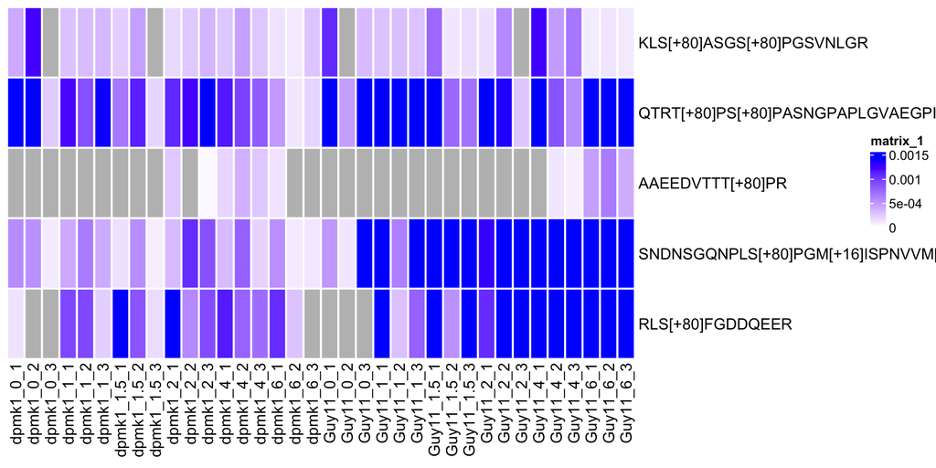

```r
m <- mdata$data
rownames(m) <- mdata$row_info[,'peptide']
colnames(m) <- colnames(mdata$data)
ComplexHeatmap::Heatmap(m, column_order = colnames(m), row_order = rownames(m), rect_gp = grid::gpar(col = "white", lwd = 2 ), col = col_fun )
```

## Replacing missing values

Now we are at the stage for doing comparisons. As before select a control and test (Spores (0) vs 1 hr in the genotype Guy11) and process that in the way done in the package and as discussed in the earlier document, this is the same code and the heatmap produced is the replaced value one.

```r
min_peptide_values <- function(d){
  apply(d$data, MARGIN = 1, min, na.rm = TRUE)
}

lowest_vals <- min_peptide_values(mdata)


select_columns_for_contrast <- function(l, treatment = NA,
                                        t_seconds = NA,
                                        control = NA,
                                        c_seconds = NA){
  td <- paste(treatment, t_seconds, sep = "_")
  td <- paste0("^", td, "$")

  cd <- paste(control, c_seconds, sep = "_")
  cd <- paste0("^", cd, "$")
  cnames_no_biorep <- unlist(lapply(strsplit(colnames(l$data), "_"), function(x) paste0(x[1], "_", x[2])))

  t_ind <- which(stringr::str_detect(cnames_no_biorep, td))
  c_ind <- which(stringr::str_detect(cnames_no_biorep, cd))

  return(list(
    treatment = l$data[,t_ind],
    control = l$data[,c_ind]
  ))
}


  selected_cols <- select_columns_for_contrast(
    mdata,
    treatment = "Guy11",
    t_seconds = 1,
    control = "Guy11",
    c_seconds = 0
  )


selected_cols
```

```
## $treatment
##         Guy11_1_1    Guy11_1_2    Guy11_1_3
## [1,] 0.0002798596 0.0002979896 0.0002806290
## [2,] 0.0016080117 0.0014762770 0.0020062610
## [3,]           NA           NA           NA
## [4,] 0.0022845043 0.0006268095 0.0027545328
## [5,] 0.0013969140 0.0002917353 0.0007842194
##
## $control
##         Guy11_0_1    Guy11_0_2    Guy11_0_3
## [1,] 0.0010807707           NA 0.0003157263
## [2,] 0.0028679916 0.0004708498 0.0027082665
## [3,]           NA           NA           NA
## [4,] 0.0004963894 0.0001115249 0.0017847892
## [5,]           NA           NA           NA
```

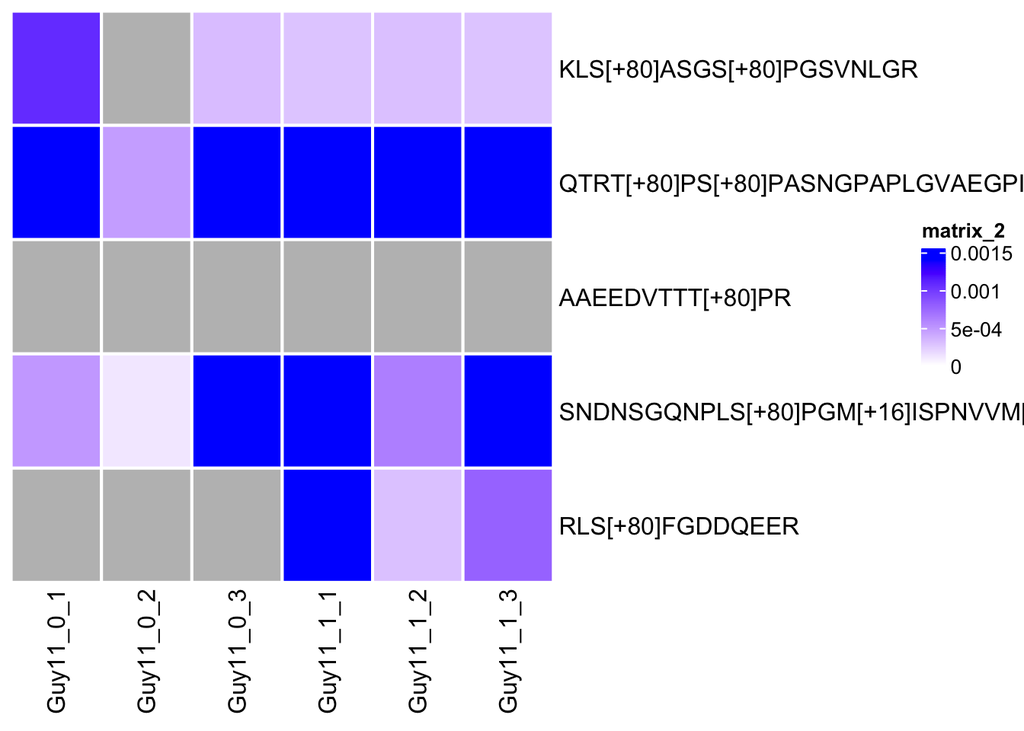

```r
m <- cbind(selected_cols$control, selected_cols$treatment)
rownames(m) <- mdata$row_info[,'peptide']
hm_missing <- ComplexHeatmap::Heatmap(m, column_order = colnames(m), row_order = rownames(m), rect_gp = grid::gpar(col = "white", lwd = 2 ), col = col_fun )
hm_missing
```

```r
replace_vals <- function(x, lowest_vals){
  to_replace <- which(is.na(x))
  x[to_replace] <- lowest_vals[to_replace]
  return(x)
}

control <- apply(selected_cols$control, MARGIN = 2, replace_vals, lowest_vals)
treatment <- apply(selected_cols$treatment, MARGIN = 2, replace_vals, lowest_vals)

control
```

```
##         Guy11_0_1    Guy11_0_2    Guy11_0_3
## [1,] 1.080771e-03 9.174940e-05 3.157263e-04
## [2,] 2.867992e-03 4.708498e-04 2.708267e-03
## [3,] 3.181009e-05 3.181009e-05 3.181009e-05
## [4,] 4.963894e-04 1.115249e-04 1.784789e-03
## [5,] 1.298511e-04 1.298511e-04 1.298511e-04
```

```r
treatment
```

```
##         Guy11_1_1    Guy11_1_2    Guy11_1_3
## [1,] 2.798596e-04 2.979896e-04 2.806290e-04
## [2,] 1.608012e-03 1.476277e-03 2.006261e-03
## [3,] 3.181009e-05 3.181009e-05 3.181009e-05
## [4,] 2.284504e-03 6.268095e-04 2.754533e-03
## [5,] 1.396914e-03 2.917353e-04 7.842194e-04
```

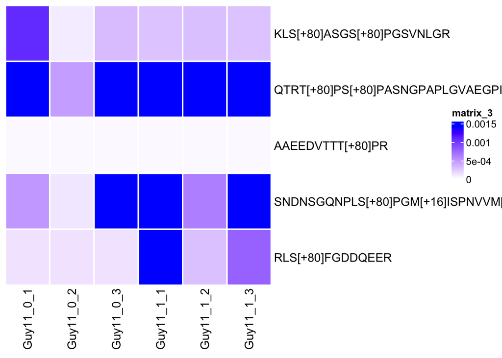

```r
m <- cbind(control, treatment)
rownames(m) <- mdata$row_info[,'peptide']
hm_replaced <- ComplexHeatmap::Heatmap(m, column_order = colnames(m), row_order = rownames(m), rect_gp = grid::gpar(col = "white", lwd = 2 ), col = col_fun )
hm_replaced
```

and side-by-side with the unreplaced for ease

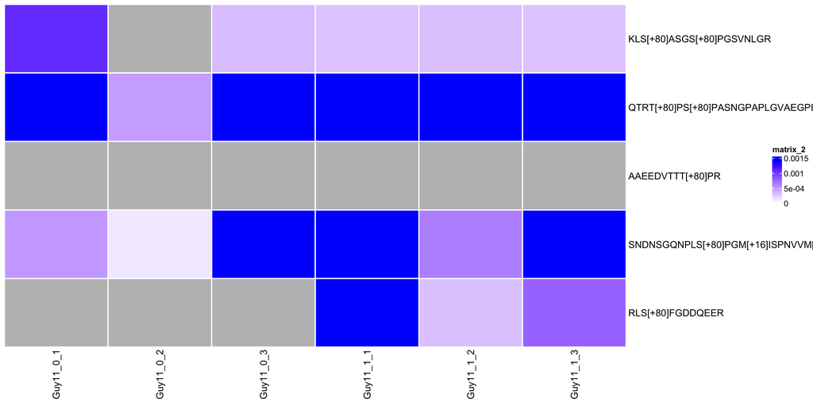

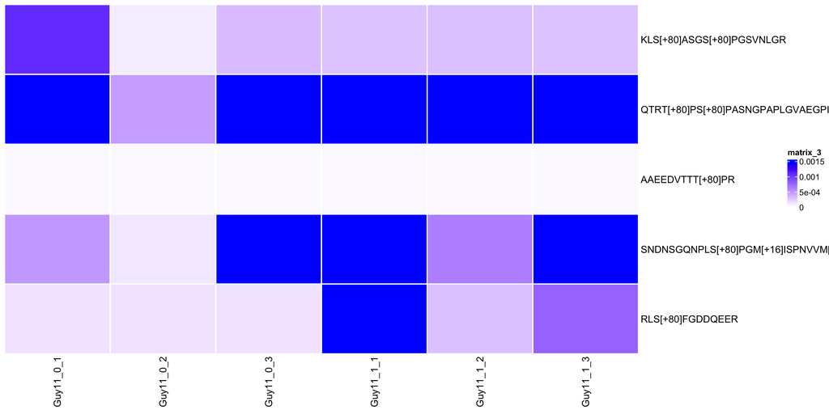

```r
hm_missing
hm_replaced
```

The replacments look fine, so we move onto doing the ratio and bootstrap calculations as per the package.

```r
get_bootstrap_percentile <- function(treatment, control, iters=10000){


  peptide_count <- dim(control)[1]
  result <- rep(NA, peptide_count)
  for (i in 1:peptide_count){
    result[i] <- tryCatch(
      {MKinfer::boot.t.test(treatment[i,], control[i,], R = iters)$p.value},
      warning = function(w){ return(NA) },
      error = function(e){
        return( NA )
      },
      finally = {})

  }
  return(data.frame(bootstrap_t_p_val = result, bootstrap_t_fdr = stats::p.adjust(result, method = 'bonferroni')))
}

mean_fold_change <- function(treatment, control){

  rowMeans(treatment, na.rm = TRUE) / rowMeans(control, na.rm = TRUE)

}
options(scipen=999)
r <- list(
  peptide = rownames(m),
  selected_cols = data.frame(control = control, treatment = treatment),
  treatment_mean_count = rowMeans(treatment, na.rm = TRUE),
  control_mean_count = rowMeans(control, na.rm = TRUE),
    fc = mean_fold_change(treatment, control),
  log_fc = log(mean_fold_change(treatment, control), 2),
  r_bootstrap_t = get_bootstrap_percentile(treatment, control, 10000)
)

results <- tibble::tibble(dplyr::bind_cols(r))
rmarkdown::paged_table(results)
```

| peptide | control.Guy11_0_1 | control.Guy11_0_2 | control.Guy11_0_3 | treatment.Guy11_1_1 | treatment.Guy11_1_2 | treatment.Guy11_1_3 | treatment_mean_count | control_mean_count | fc | log_fc | bootstrap_t_p_val | bootstrap_t_fdr |
| --- | --- | --- | --- | --- | --- | --- | --- | --- | --- | --- | --- | --- |
| KLS[+80]ASGS[+80]PGSVNLGR | 0.00108077070 | 0.00009174940 | 0.00031572630 | 0.00027985960 | 0.00029798960 | 0.00028062900 | 0.00028615940 | 0.00049608213 | 0.5768388 | -0.7937600 | 0.5558414 | 1.0000000 |
| QTRT[+80]PS[+80]PASNGPAPLGVAEGPITPR | 0.00286799160 | 0.00047084980 | 0.00270826650 | 0.00160801170 | 0.00147627700 | 0.00200626100 | 0.00169684990 | 0.00201570263 | 0.8418156 | -0.2484239 | 0.7228527 | 1.0000000 |
| AAEEDVTTT[+80]PR | 0.00003181009 | 0.00003181009 | 0.00003181009 | 0.00003181009 | 0.00003181009 | 0.00003181009 | 0.00003181009 | 0.00003181009 | 1.0000000 | 0.0000000 | NA | NA |
| SNDNSGQNPLS[+80]PGM[+16]ISPNVVM[+16]VDEHGR | 0.00049638940 | 0.00011152490 | 0.00178478920 | 0.00228450430 | 0.00062680950 | 0.00275453280 | 0.00188861553 | 0.00079756783 | 2.3679685 | 1.2436499 | 0.2578566 | 1.0000000 |
| RLS[+80]FGDDQEER | 0.00012985110 | 0.00012985110 | 0.00012985110 | 0.00139691400 | 0.00029173530 | 0.00078421940 | 0.00082428957 | 0.00012985110 | 6.3479598 | 2.6662930 | 0.1619377 | 0.6477508 |

The table can be scrolled through left to right, we can see that the values appear to be computed correctly and make sense.

### Output data to excel files for ease

Here I just dump my data objects to an Excel file.

```r
library(writexl)

#cleaned_small
#pdiff

all_mat_dat <- as.data.frame(cbind(mdata$row_info, mdata$data))
sel_cols_missing <- as.data.frame(cbind(mdata$row_info, selected_cols$control, selected_cols$treatment))
sel_cols_replaced <- as.data.frame(m <- cbind(mdata$row_info, control, treatment))

x <- list(
  cleaned_small = cleaned_small,
  loaded_into_pepdiff = pdiff,
  as_matrix_techreps_merged = all_mat_dat,
  selected_cols_missing_values = sel_cols_missing,
  selected_cols_replaced_values = sel_cols_replaced,
  results = results
)

write_xlsx(x, here::here("cleaned","005_all_tables.xlsx"))
```